# Project Transplant kidney rejection High Dimensional Data Analysis

Jan Alexander[^1]

Annabel Vaessens[^2]

Steven Wallaert[^3]

22 05 2020

Abstract

# Exploratory Analysis

In this section general descriptive statistics are given and multiple methods for high dimensional data exploration are used.

## Basic descriptive summary

In this study 54675 gene expression levels of 282 samples were analysed. In total, 76 or 27% of the transplanted kidneys were rejected.

Several descriptive statistics (mean, sd, median, iqr, min, and max) were calculated for every gene and kidney rejection status combination. This resulted in 2 (accepted vs. rejected) distributions of every statistic across genes. Note that these statistics were only calculated to perform a visual inspection.

The resulted plot is presented in figure 1. From this figure we can see there are, at least on this level, differences between the two groups. Most notable are the mean and median expression levels which tend to be closer to the overall mean (across groups) expression levels in the *accepted* group and more varying in the *rejected* group. There seems to be more variablity in the measures of dispersion in the *rejected* group. Finally there are minimal differences between the min/max expression level distributions, perhaps suggesting that gene expression levels in the *rejected* group are slightly less extreme than in the *accepted* group.

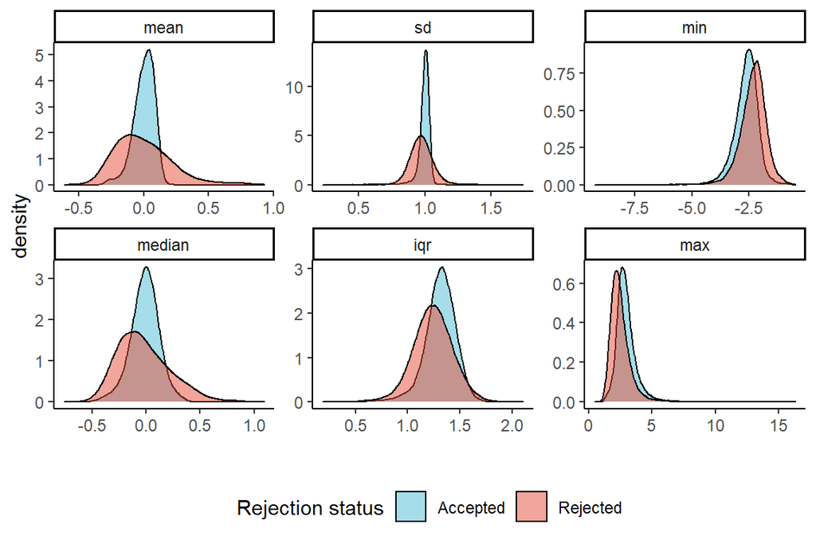

Descriptive statistics across grenes and between groups. Note that the data were centered before calculating the statistics.

## Advanced exploratory analyses

Multiple methods for exploration and visualisation of high dimensional data were applied (sparse PCA, MDS, sparse LDA, LLE, ISOMAP, Sammon Mapping, Diffusion maps, and t-SNE), yet without clear results. Because the sparse LDA gave the best results we discuss the results here and refer to the appendices to for the results of the other techniques.

The sparse LDA was performed to find potential candidate genes for future investigation. Due to computational constraints (our system ran out of memory) we needed to split the data set in 3 parts (each part consisting of 282 observations on 18225 genes). We considered this approach to be valid since we only used it as an exploratory tool. In total 116 genes (or 0.2%) had non-zero loadings.

By using these gene’s loadings we calculated the scores of the linear discriminant for every sample and used these to construct the following graph.

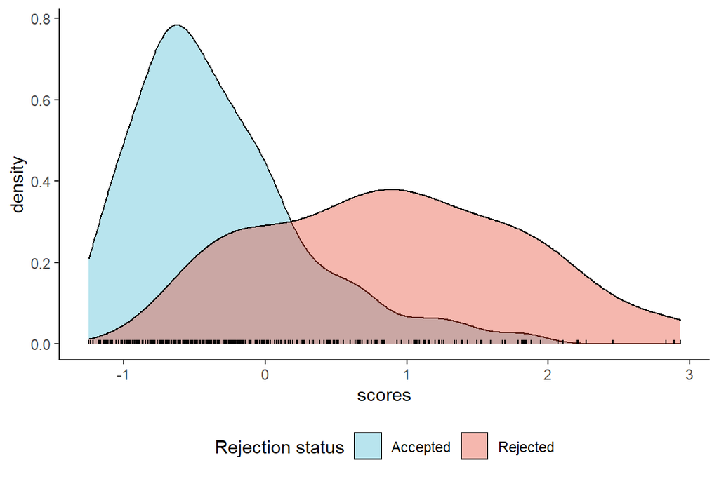

Density plot of linear discriminant scores based on the selected subset of genes.

From this graph we can see that to a degree a distinction can be made, albeit with a substantial overlap.

## Conclusions Exploratory Analysis

Although differences between groups could be found within the data, no articulate distinction between the rejection status groups could be made with any of the used methods. This finding suggests there is relevant information at the genetic level w.r.t. transplant kidney rejection, but more factors need to be taken into account in order to arrive at a better understanding.

The main directions of variability in the gene expression dataset do not coincide with the separation between the rejection status groups. Nevertheless, certain genes were identified as potentially closely related to the differentiation between the two groups using sparse LDA.

# Differentially expressed genes between kidney rejection groups

In order to find out which genes are differentially expressed between rejection status groups null hypotheses were tested against alternative hypotheses as follows.

$$\left.\begin{aligned} H_{0,i}: \mu_{rejected, i} = \mu_{accepted,i} \\ H_{a,i}: \mu_{rejected, i}\neq \mu_{accepted,i} \end{aligned} \right \} \quad with \space i = \{1,\dots,54675\}$$

In these hypotheses $\mu_{rejected,i}$ and $\mu_{accepted,i}$ are the population means of the gene expression level of the ith gene in the rejected and accepted kidney rejection group respectively. Before testing, a visual inspection of 30 QQ plots, from 15 randomly drawn variables, was done to assess whether the variables follow a normal distribution for both groups separately. These QQ plots showed that some genes were normally distributed, but also that many genes were not.

Nevertheless, two-sided Welch t-tests were performed on the uncentered data to determine whether the two groups can be differentiated based on the gene expression level for every gene. The choice for the Welch t-test is motivated by the presence of unequal variances and **differences in sample size** between the two groups, even though not all genes were normally distributed. We included a small random subset 6 QQ plots in the appendix so the reader, if she/he wishes, can have a rough idea of the divergence from normality.

To address the multiple testing problem at this large scale (54675 simultaneous tests), the FDR is controlled at 0.10 through application of the method of Benjamini and Hochberg (1995).

To summarise the results we constructed a histogram of both the regular and adjusted p-values or q-values.

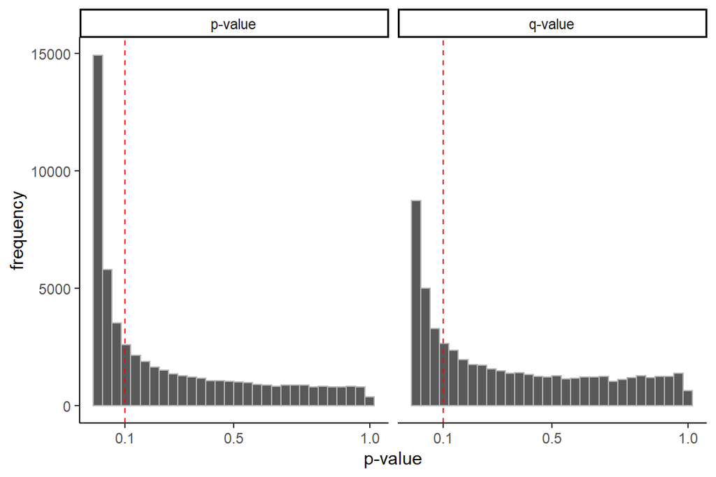

Histograms of regular and adjusted p-values. The dashed line indicates the threshold.

Both histograms reveal non-uniform distributions. More importantly, they have many small values, indicating that for many genes the null hypothesis was rejected. Based on the q-values, there were 18081 rejected null hypotheses. As such we conclude that the mean gene expression differs between the accepted and rejected kidney groups for those 18081 genes. As the FDR is controlled at 10%, it is expected to have around 1808 false discoveries.

Next, the normalised test statistics (z-scores) are plotted and compared to the local false discovery rate.

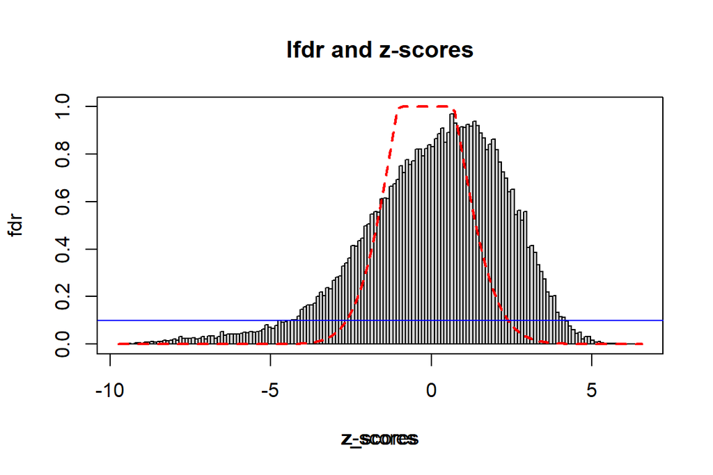

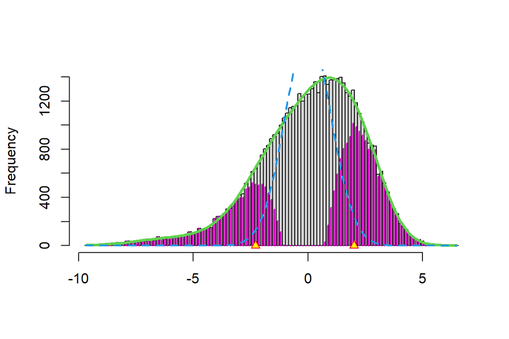

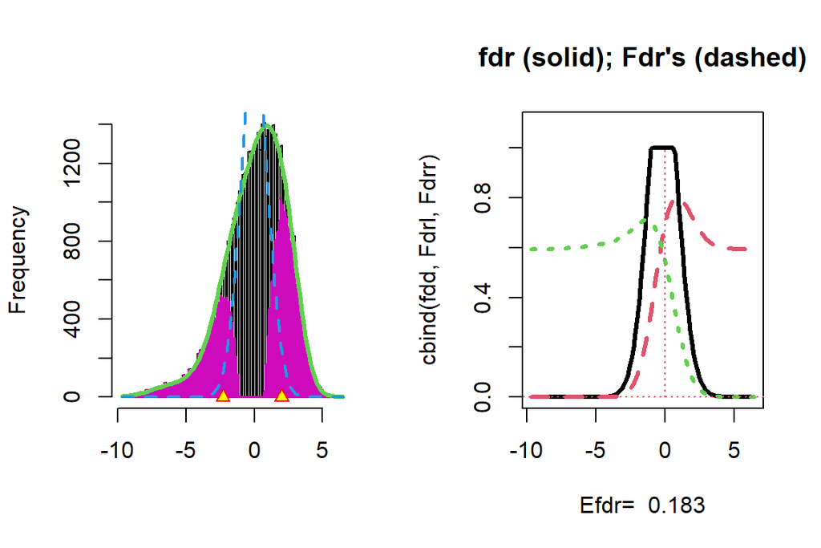

# Prediction of kidney transplant rejection

The objective of this final part is to construct a classifier for kidney acceptance or rejection based on the measured gene expressions. Three approaches are compared: lasso, ridge regression and principle component regression. These approaches will be compared based on the AUC. The final modelling approach is chosen as the one that shows the largest cross-validated AUC. The cutoff is chosen based on the F1-score. The dataset is split into a training and test dataset.

## Lasso regression

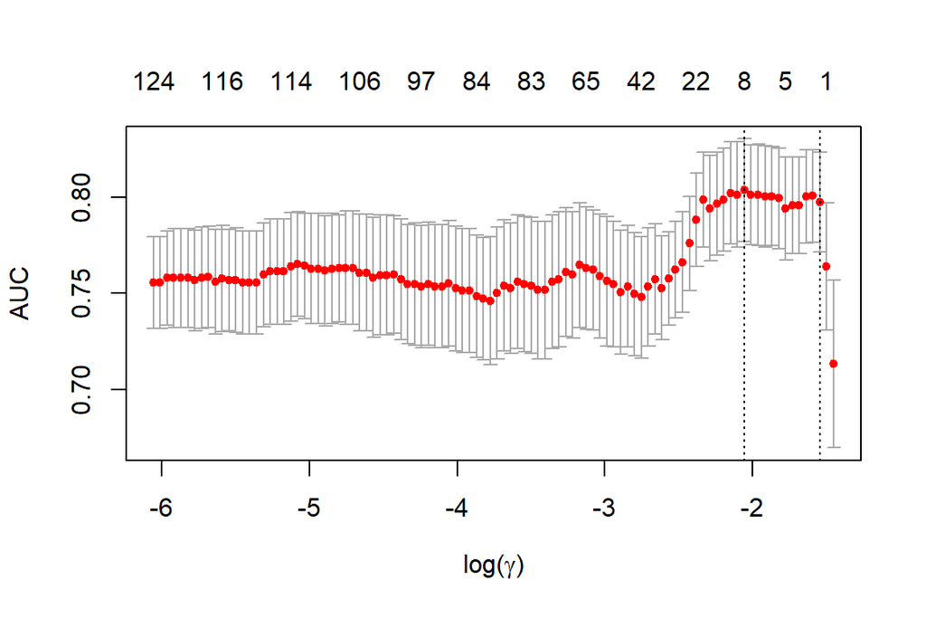

The ROC curve, estimated with the cross-validation dataset, is shown below:

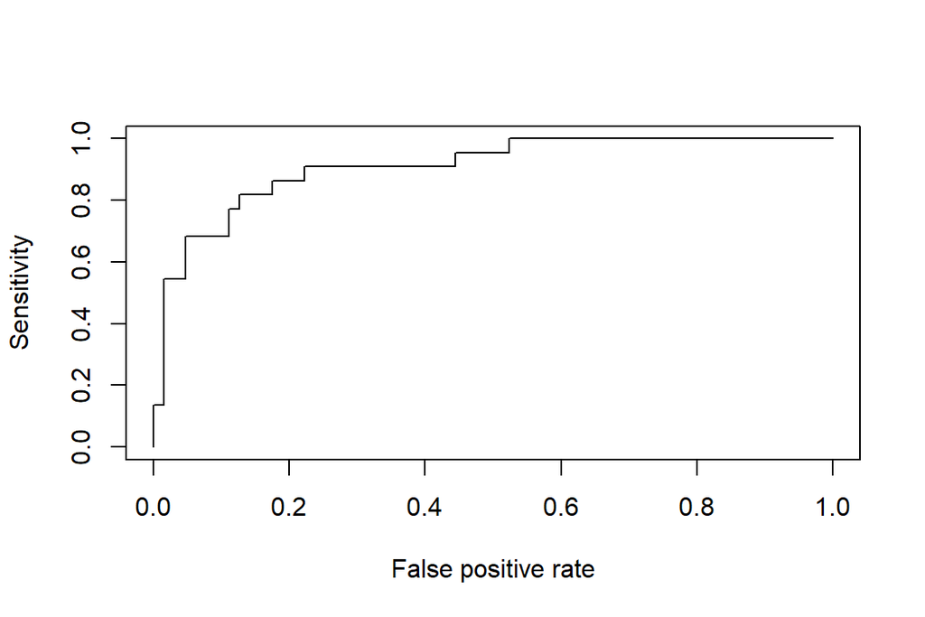

This model only uses 8 of the genes: 396, 11720, 13463, 17178, 29063, 29276, 30941, 49664. Compared to the interesting genes found with the Sparse LDA method: This is a considerable dimensional reduction. This is illustrated below. This figure shows the loadings of the 8 selected values.

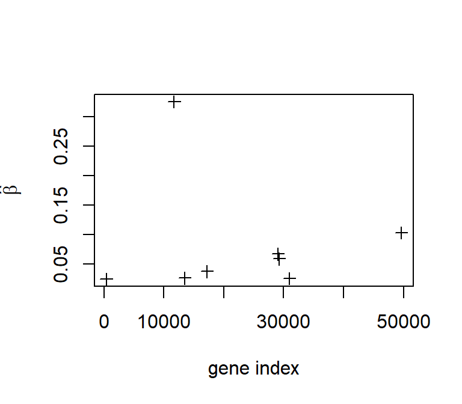

When performing the same analysis on this reduced dataset as was performed on the complete dataset, we see that the gene expressions become a bit more separable.

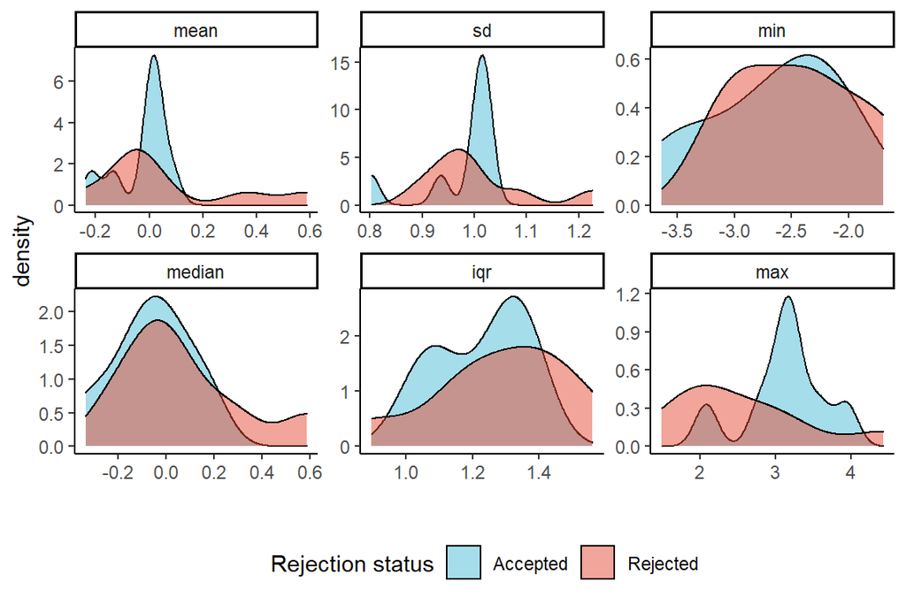

Descriptive statistics across grenes and between groups. Note that the data were centered before calculating the statistics.

## Ridge regression

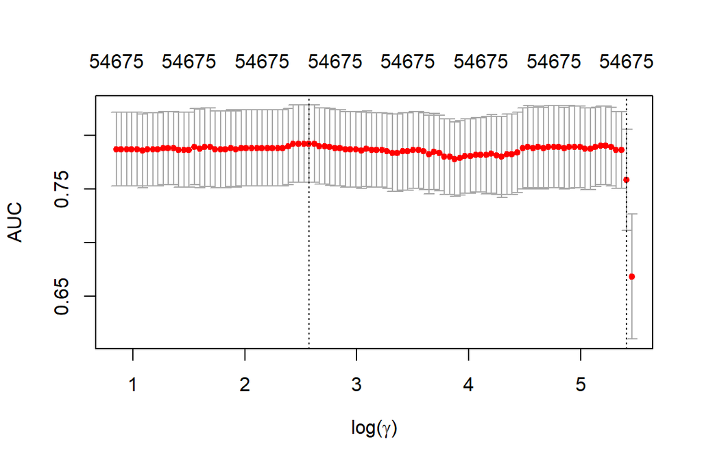

The ROC curve, estimated with the cross-validation dataset, is shown below:

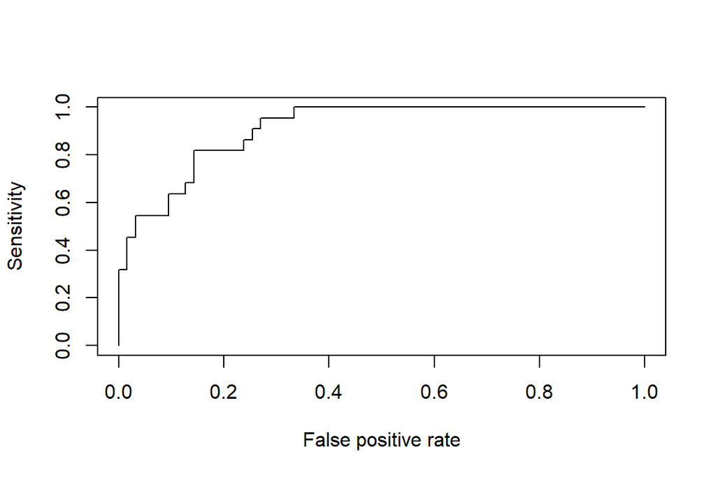

## Principal component regression

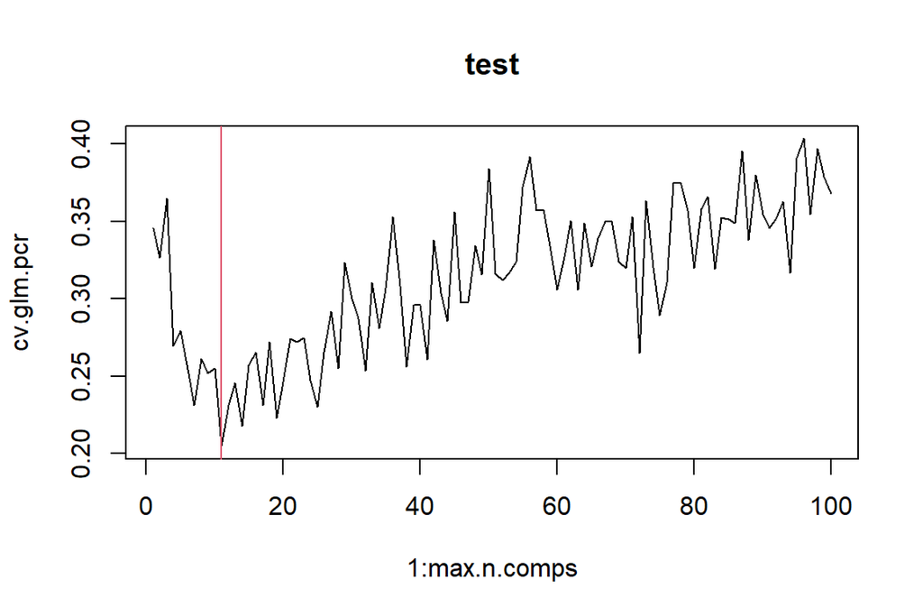

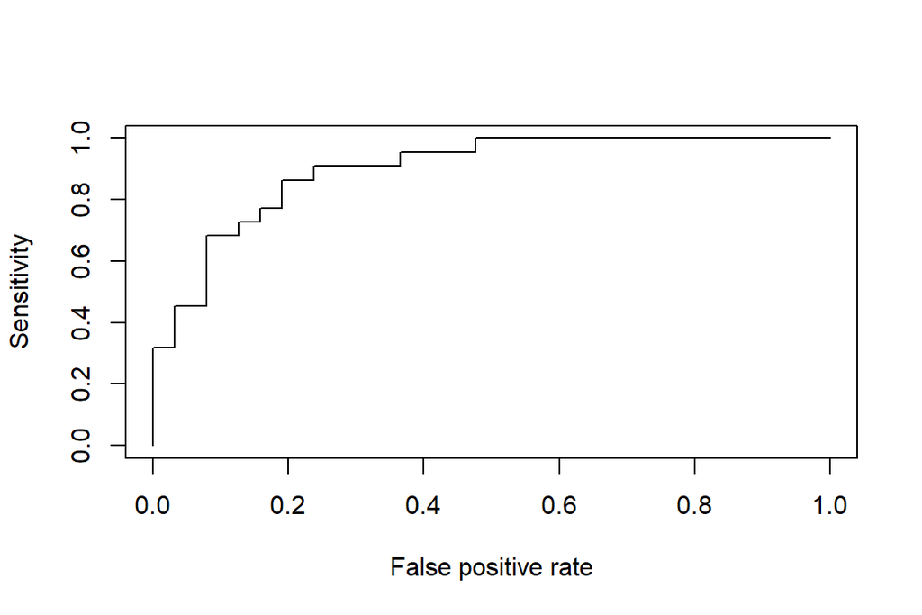

AUC is 0.898.

## Final model evaluation

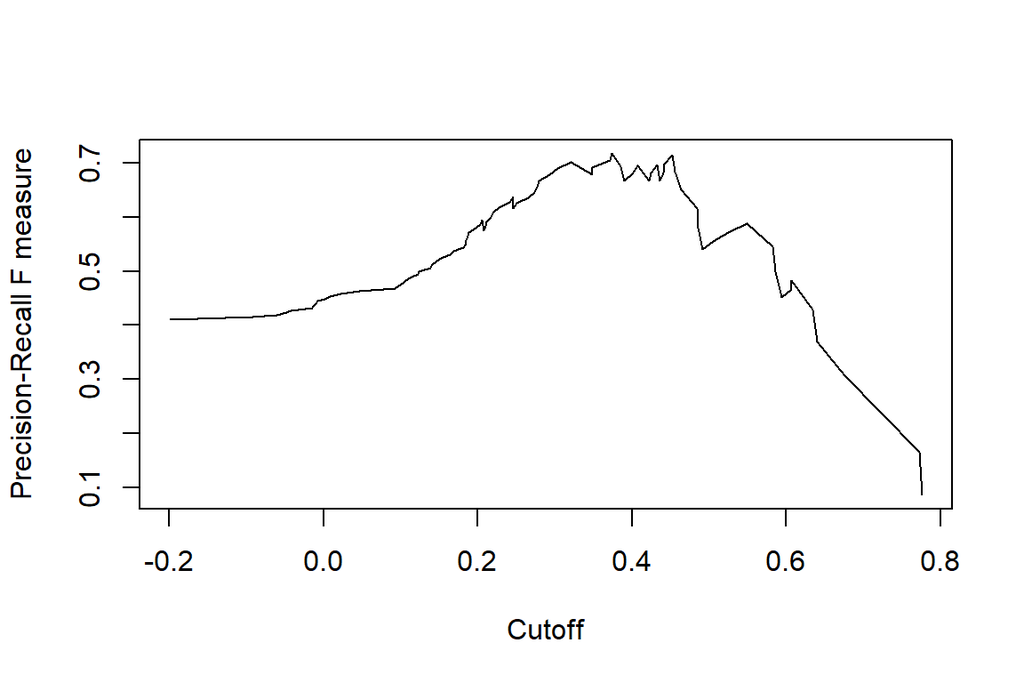

[output not shown]

This behaviour could be *explained* (or at least understood a little better) when looking back at the exploratory analysis. Here it was already clear that the gene expressions of the patients with rejected kidneys overlap with those of the patients with accepted kidneys. Both are not perfectly separable.

# Appendices

## Exploration methods for high dimensional data

### Sparse principle components analysis

```
##  Fold  1  out of  5
##  Fold  2  out of  5
##  Fold  3  out of  5
##  Fold  4  out of  5
##  Fold  5  out of  5
```

```
## Call:
## SPC.cv(x = GeneExpression_C)
##
##
## Cross-validation errors:
##    Sumabsvs CV Error  CV S.E. # non-zero v's
## 1     1.200  3072720 1069.866            2.8
## 2     1.622  3072688 1067.905            4.2
## 3     2.044  3072646 1066.778            7.4
## 4     2.467  3072600 1065.211            9.4
## 5     2.889  3072540 1062.144           13.6
## 6     3.311  3072476 1061.874           16.8
## 7     3.733  3072400 1061.760           22.0
## 8     4.156  3072305 1060.237           27.4
## 9     4.578  3072197 1061.406           32.6
## 10    5.000  3072079 1063.205           40.0
##
##  Best sumabsv value (lowest CV error):  5
##
##  Smallest sumabsv value that has CV error within 1 SE of best CV error:  1.2
```

```
## 1234567891011121314151617181920
## 1234567891011121314151617181920
```

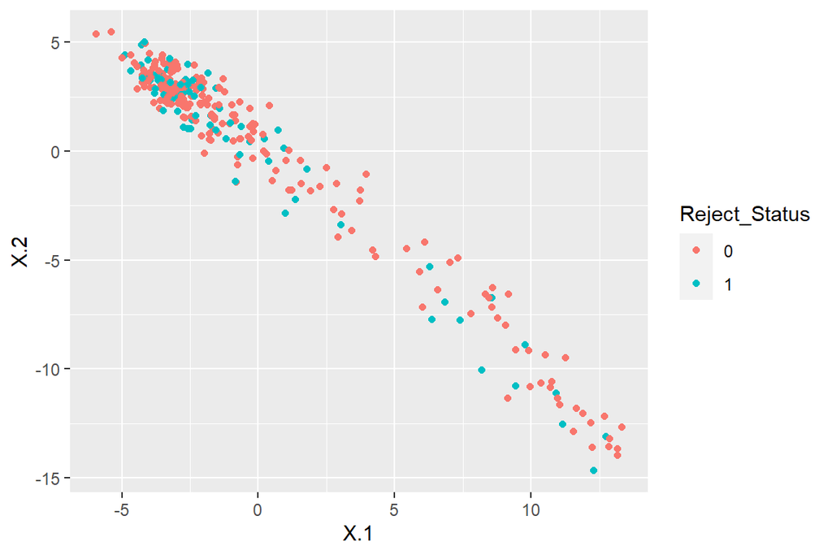

Unfortunately, naive sparce principle component analysis cannot be used to make a distinction between the accepted and rejected kidneys.

### Multi-dimensional scaling:

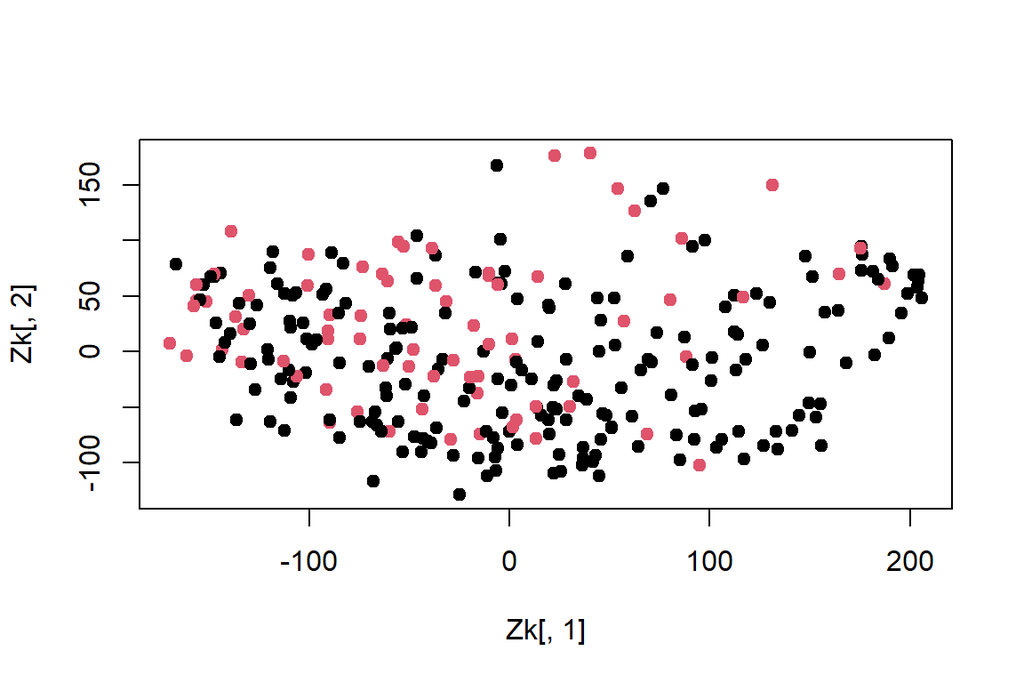

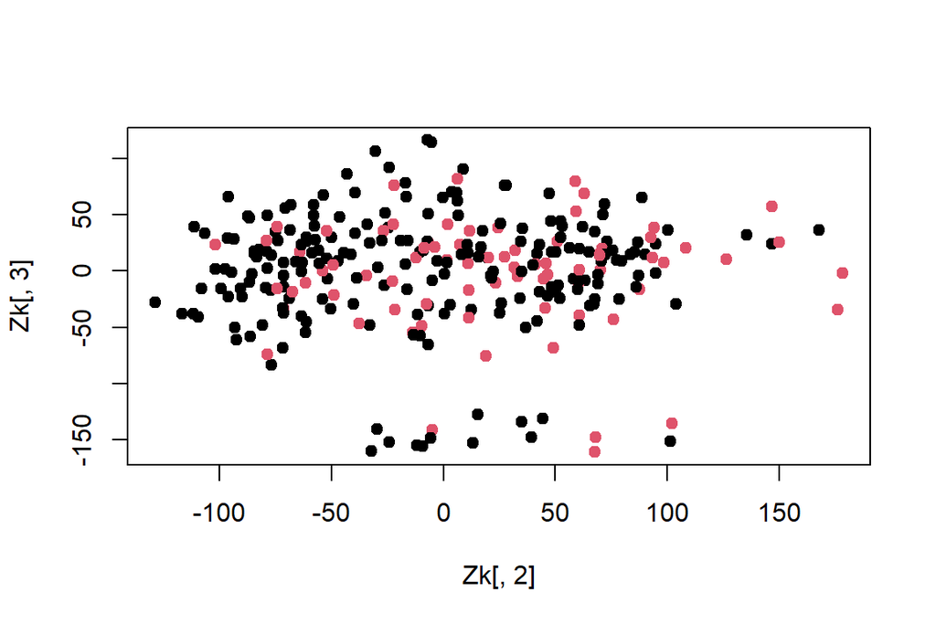

In the biplots of the three first dimensions of the svd (), no distinction can be made between rejected and accepted kidneys.

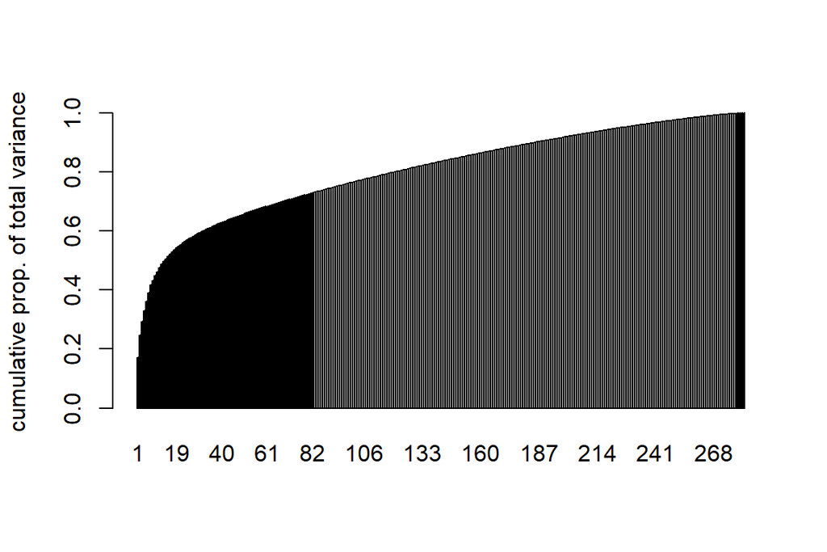

In the scree plot it can be seen that the two first dimensions account for only 25% of the total variance in the dataset and the first three dimensions for 29%. To account for 80% of the total variance, 120 dimensions are needed.

### Sammon mapping

Sammon mapping is also a nonlinear dimension reduction method. The cost function of the Sammon method is similar to that of MDS, except that it is adapted by dividing the squared error in the representation of each pairwise Euclidean distance by the original Euclidean distance in the high-dimensional space. In this way, local structure is better preserved than in MDS. The result is in figures : no distinction can be made between the two groups.

```
## Initial stress        : 0.28532
## stress after  10 iters: 0.21735, magic = 0.004
## stress after  20 iters: 0.16971, magic = 0.009
## stress after  28 iters: 0.13928
```

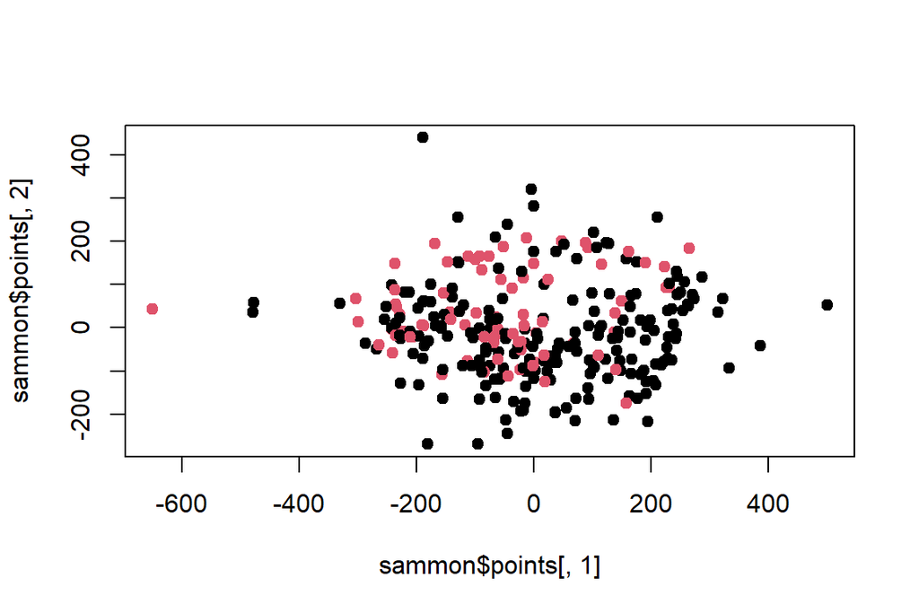

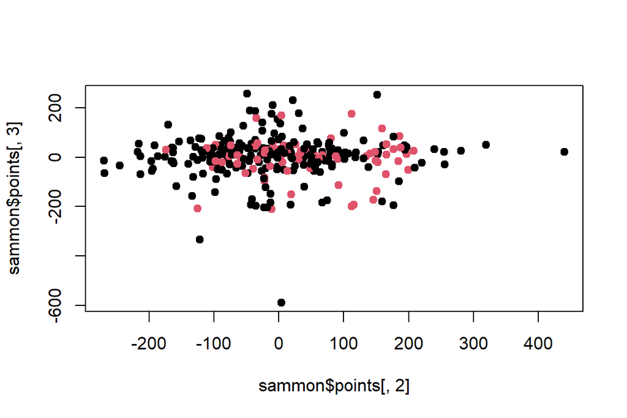

### Diffusion maps

Diffusion mapping is also a nonlinear dimension reduction method based on the eigenvectors and eigenvalues of the data. The global strucure of the data is mapped by integration of local similarities at different scales. It works with probablities of point x randomly walking to y, and is based on the heat diffusion equation.

```
## Performing eigendecomposition
## Computing Diffusion Coordinates
## Used default value: 3 dimensions
## Elapsed time: 112.6 seconds
```

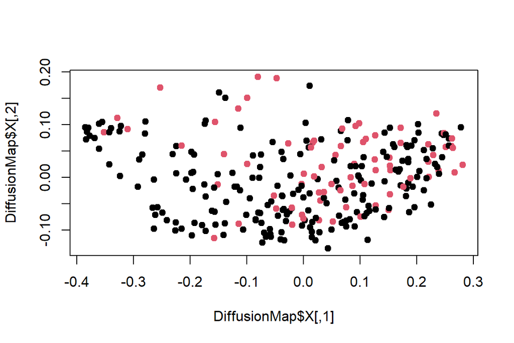

From figure , no distinction between the two groups can be made with diffusion maps.

### t-SNE

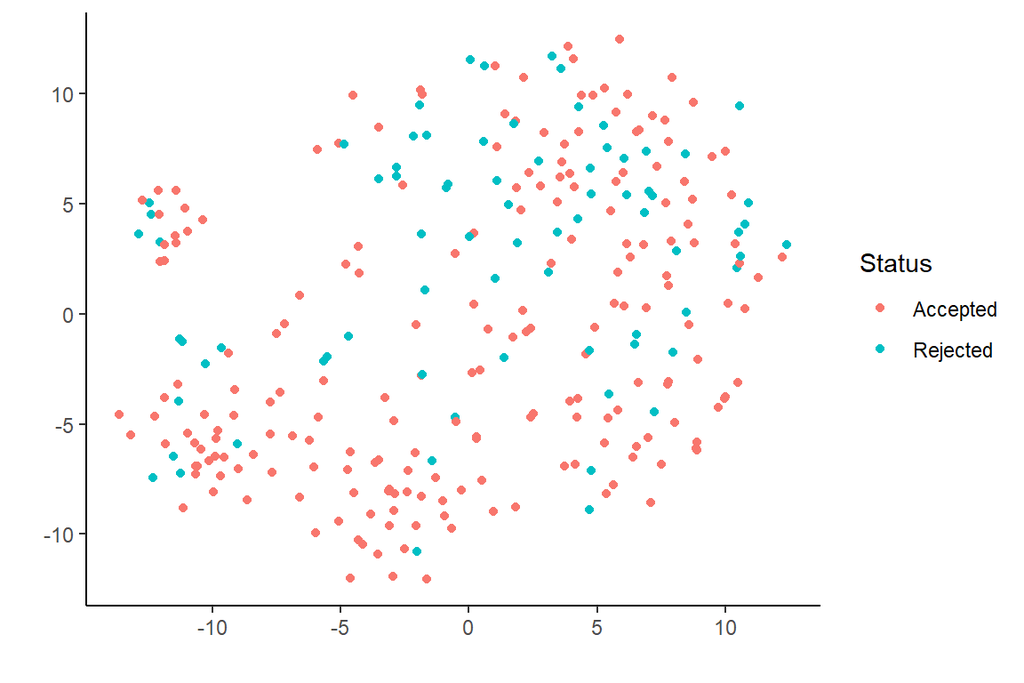

Two dimensional representation of the data through application of t-SNE

## QQ-plots

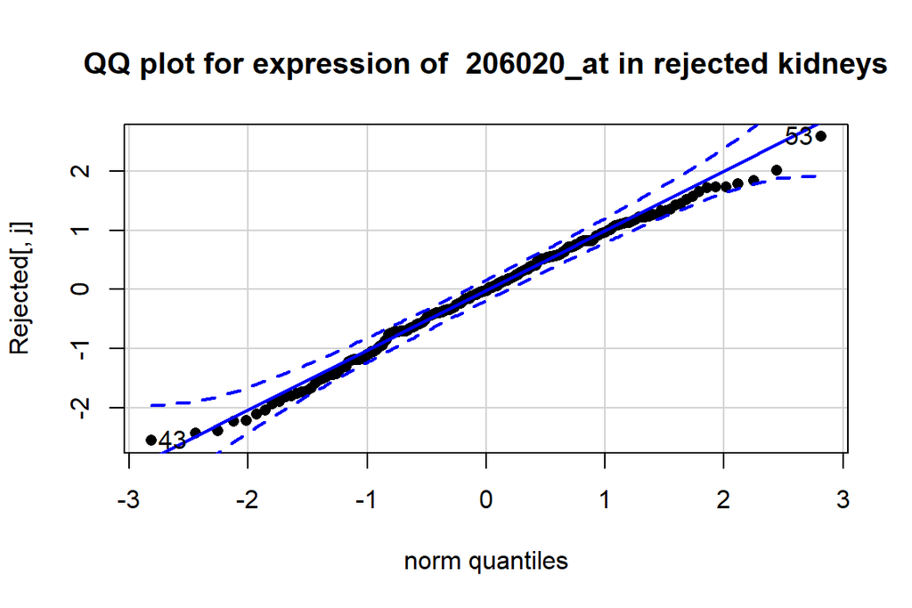

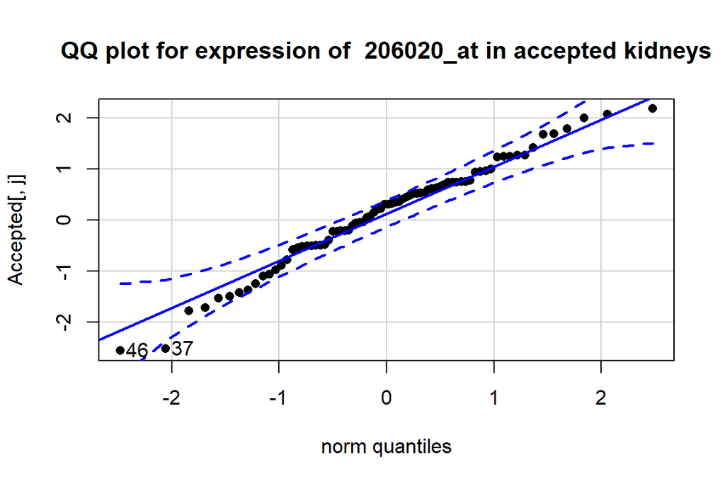

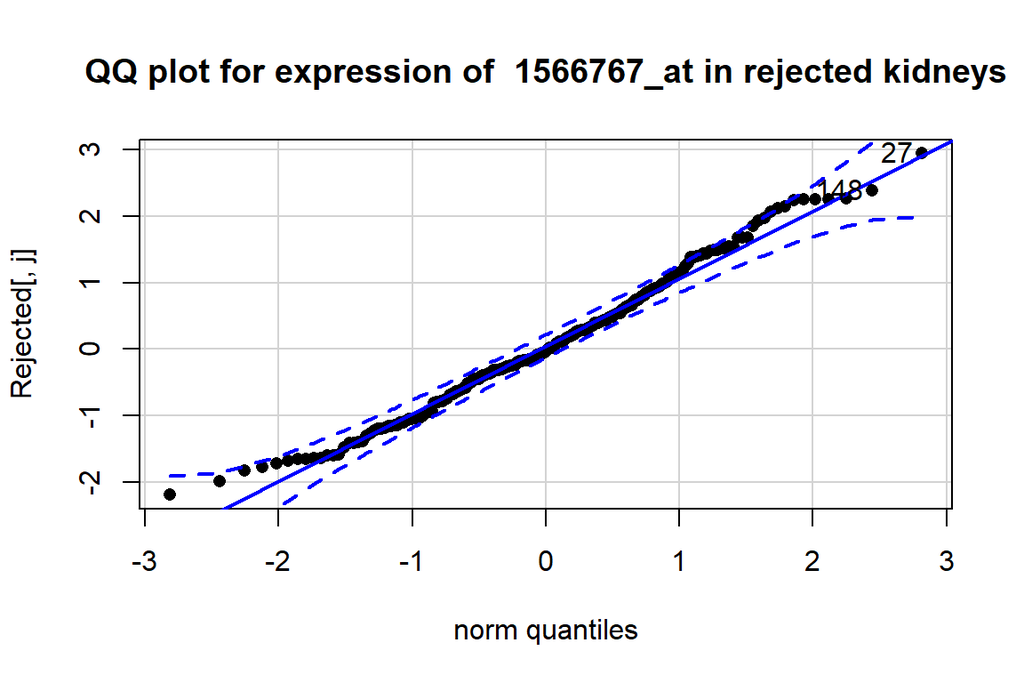

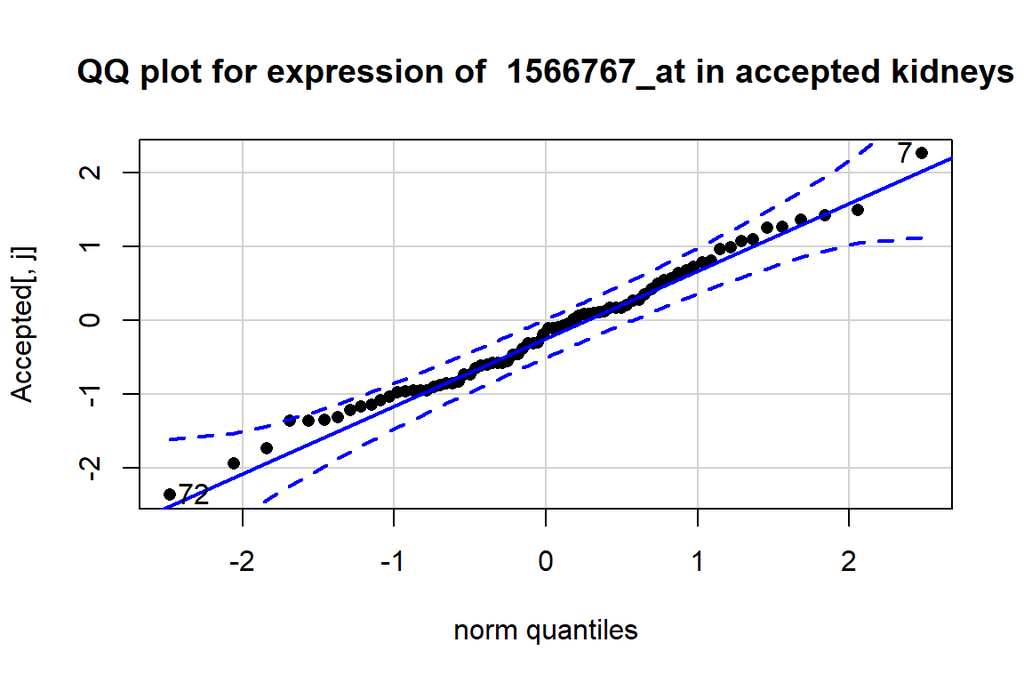

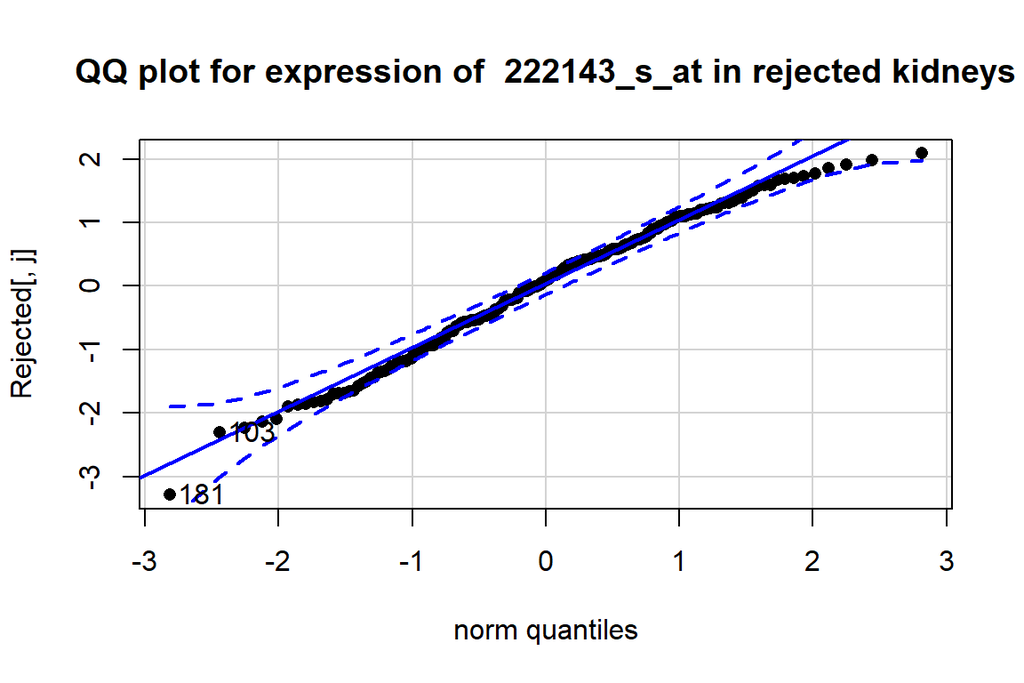

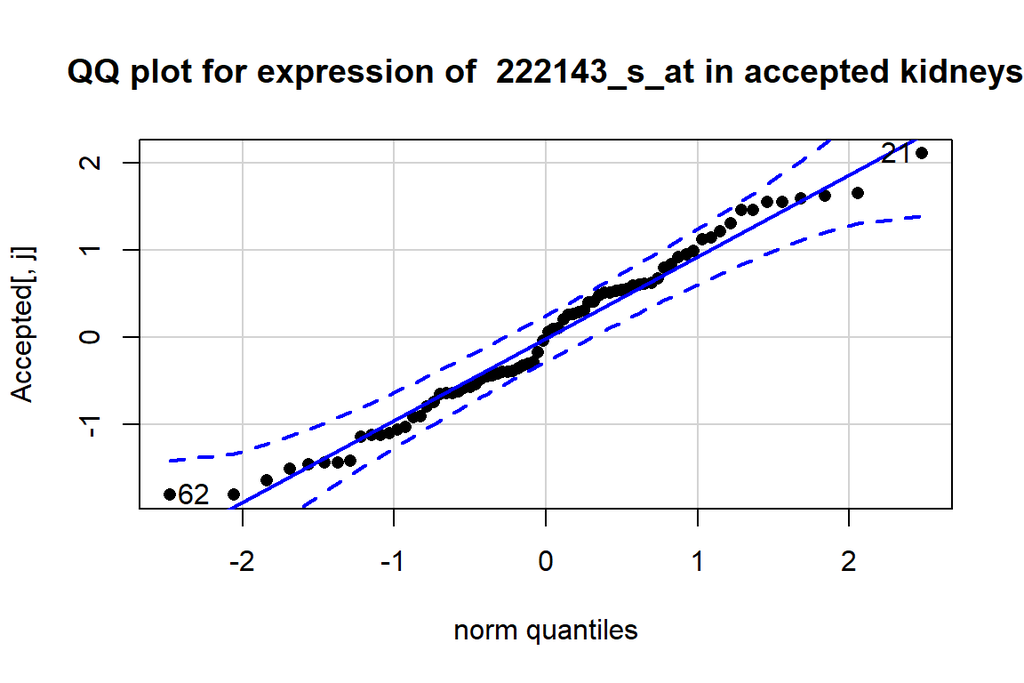

# References

Benjamini Y and Hochberg Y, 1995. Controlling The False Discovery Rate - A Practical And Powerful Approach To Multiple Testing. Journal of the Royal Statistical Society. Series B: Methodological 57, 289-300.

Roweis ST and Saul LK, 2000. Nonlinear dimensionality reduction by locally linear embedding. Science, 290, 2323-2326.

Tenenbaum JB, De Silva V and Langford JC, 2000. A global geometric framework for nonlinear dimensionality reduction. Science, 290, 2319-2323.

[^1]: jan.alexander@ugent.be
[^2]: annabel.vaessens@vub.be
[^3]: steven.wallaert@ugent.be